# Project R

Maria

2023-12-22

## What are the characteristics of the Yellow Taxi trips in New York?

#### This work analyses data about taxi trips in New York based on the dataset provided by [NYC Open Data](https://data.cityofnewyork.us/Transportation/2020-Yellow-Taxi-Trip-Data/kxp8-n2sj) and [The Official Website of the City of New York](https://www.nyc.gov/site/tlc/about/tlc-trip-record-data.page). Each row represents information about a Yellow Taxi trip in New York in January 2023. The original dataset contained 3 million observations and 19 variables. The size of the dataset was too big so it was randomly sampled. After sampling, cleaning and transformating there are **100 000** observations and **9** variables:

- **tpep_pickup_datetime** - The date and time when the meter was engaged.
- **tpep_dropoff_datetime** - The date and time when the meter was disengaged.
- **passenger_count** - The number of passengers in the vehicle.
- **trip_distance** - The elapsed trip distance in miles reported by the taximeter.
- **PULocationID** - TLC Taxi Zone in which the taximeter was engaged
- **DOLocationID** - TLC Taxi Zone in which the taximeter was disengaged
- **payment_type** - A numeric code signifying how the passenger paid for the trip (1= Credit card, 2= Cash)
- **tip_amount** - Tip amount (automatically populated for credit card tips. Cash tips are not included)
- **total_amount** - The total amount charged to passengers. Does not include cash tips.

### The summary statistics are shown below. We can see that average distance is 3.4 miles, average tip amount is $3.4, average cost of a trip is $27 and average duration of the trip is 14 minutes.

|  | trip_distance | tip_amount | total_amount | duration |
| --- | --- | --- | --- | --- |
|  | Min. : 0.010 | Min. : 0.000 | Min. : 1.00 | Min. : 0.000 |
|  | 1st Qu.: 1.100 | 1st Qu.: 1.000 | 1st Qu.: 15.48 | 1st Qu.: 7.183 |
|  | Median : 1.800 | Median : 2.800 | Median : 20.15 | Median :11.533 |
|  | Mean : 3.383 | Mean : 3.398 | Mean : 27.15 | Mean :14.418 |
|  | 3rd Qu.: 3.350 | 3rd Qu.: 4.200 | 3rd Qu.: 28.56 | 3rd Qu.:18.250 |
|  | Max. :29.990 | Max. :29.990 | Max. :194.97 | Max. :79.917 |

## Number of trips

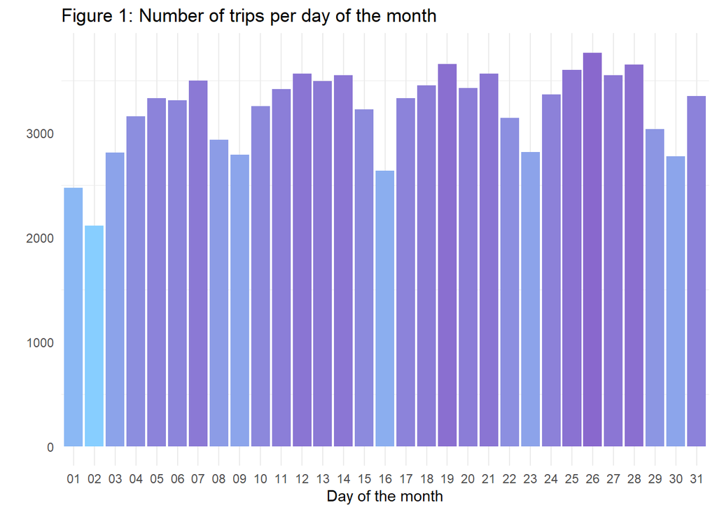

### Indeed, Thrurdsay, Friday and Saturday are on average busier than other days.

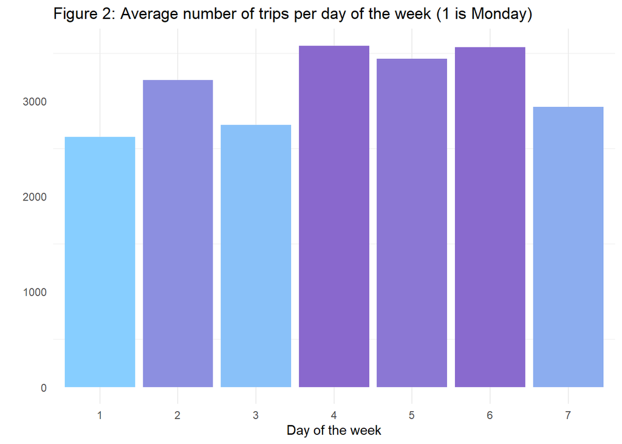

### Majority of the trips start around 8 am with the number of trips increasing gradually throughout the day with the peak hours at 18-19 o’clock and then decreasing with the lowest traffic at 5-6 am.

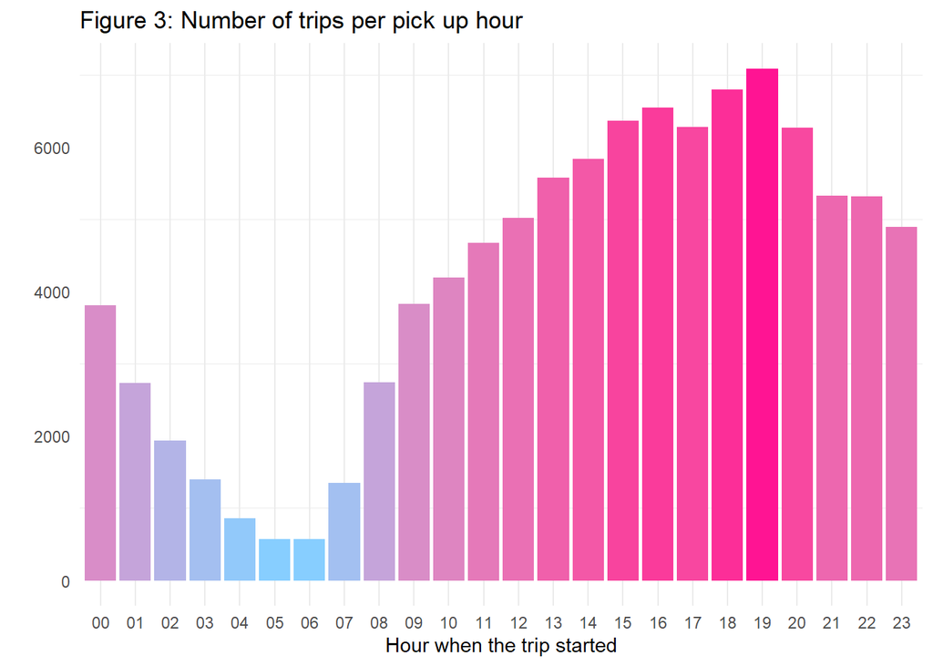

## Number of passengers

### Most of the trips count one passenger.

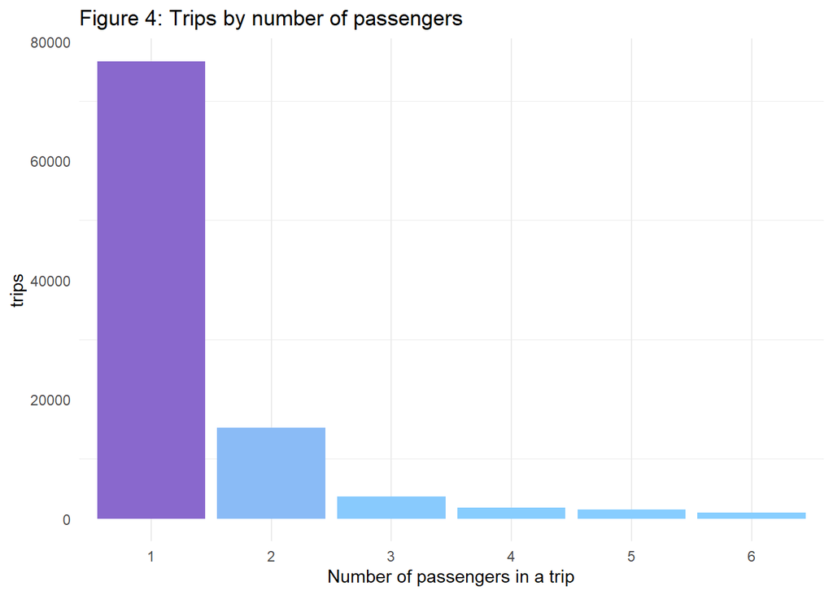

## Duration

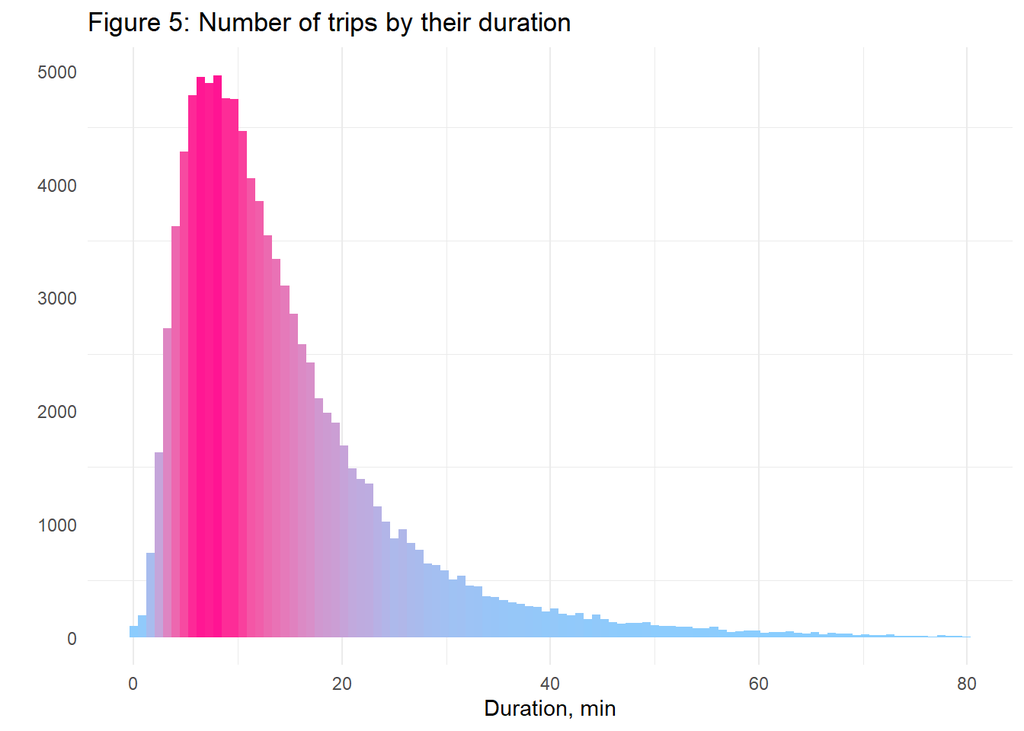

### Average duration of the trip does not differ throughout the week and remains around 15 minutes.

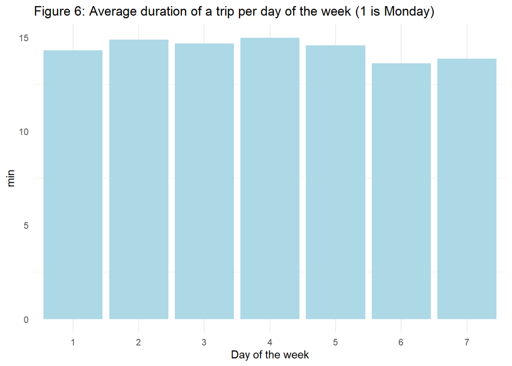

### Average duration of the trip is slightly higher at 15-18h.

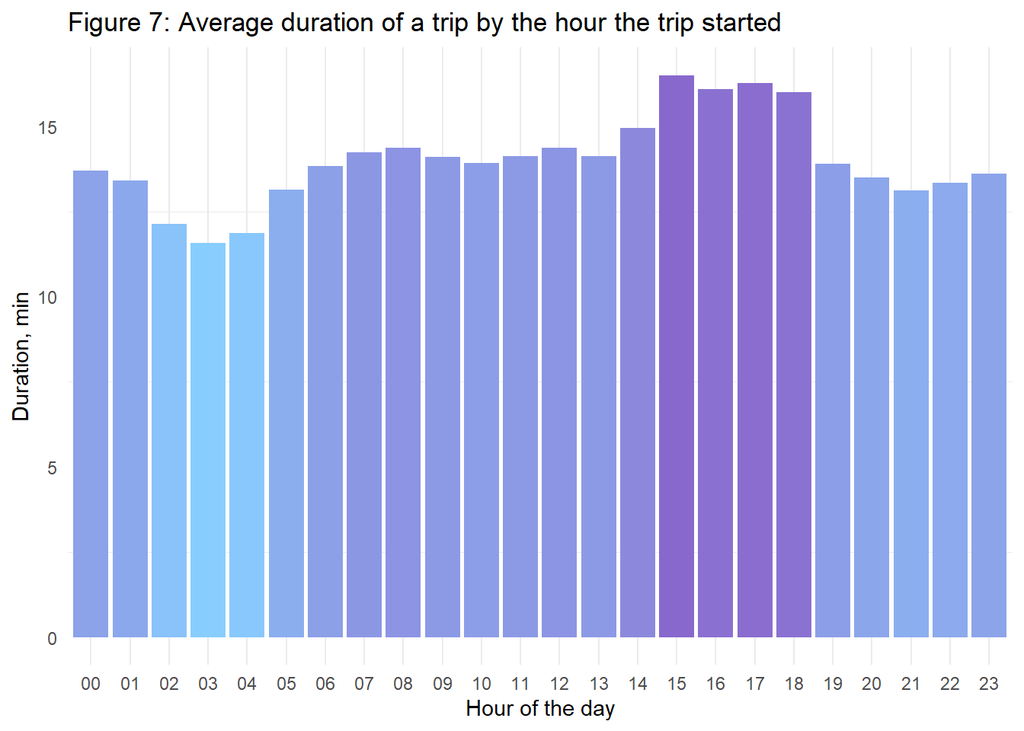

## Speed

### Average speed of the trip is higher at night and early in the morning peaking at 6 am and is lowest at rush hours 16-18 o’clock.

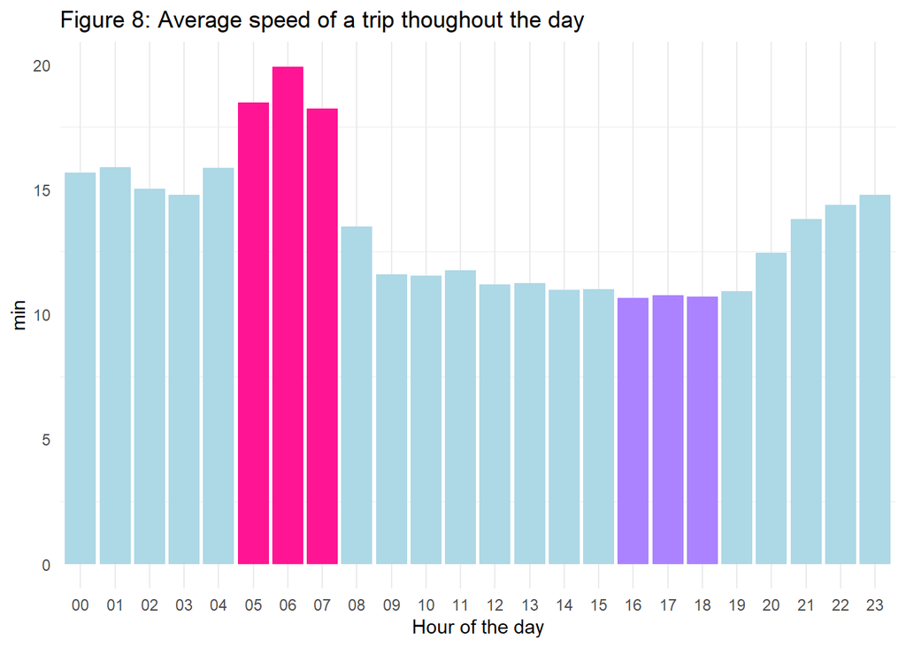

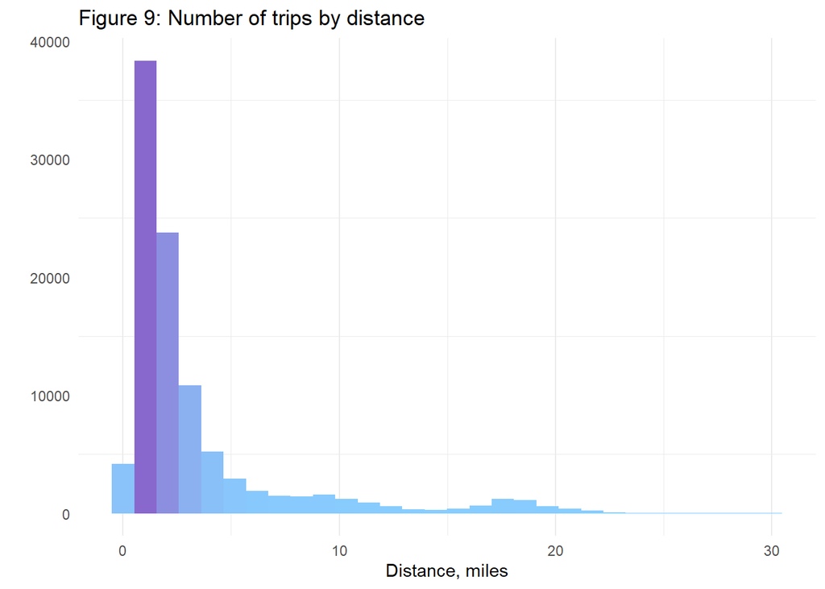

### Average distance of the trips does not differ significantly by number of pasengers.

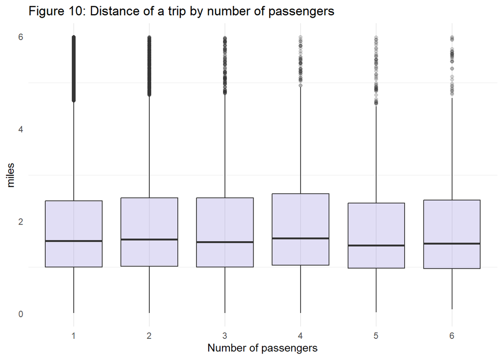

## Payment method, tips and total cost

### Most of the trips cost less than $25.

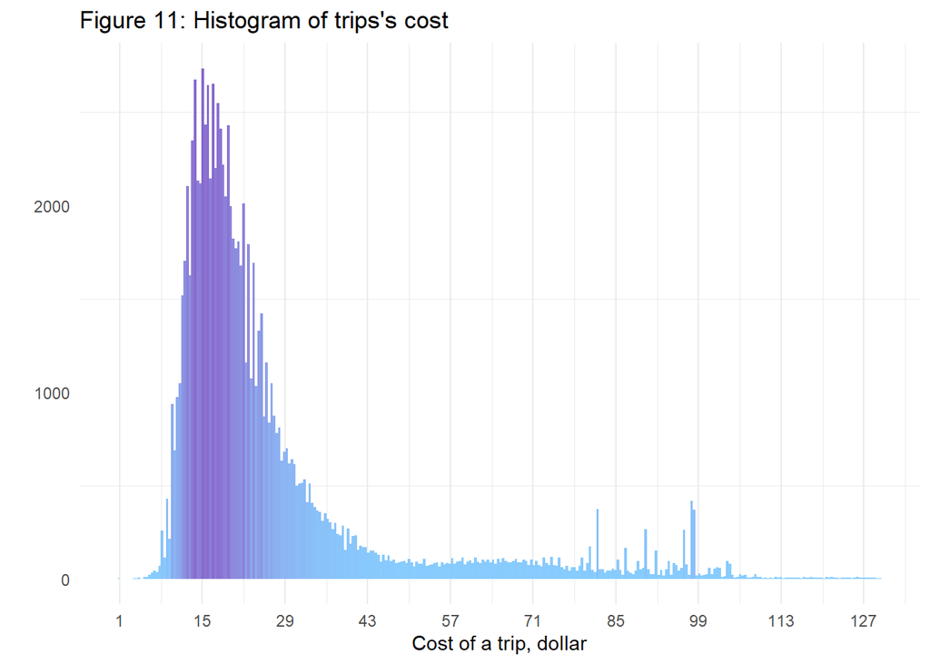

### The majority of the trips is paid by credit card (1 Credit Card, 2 Cash).

| payment_type | count |
| --- | --- |
| 1 | 82181 |
| 2 | 17819 |

### Most of the trips have less than $5 tips.

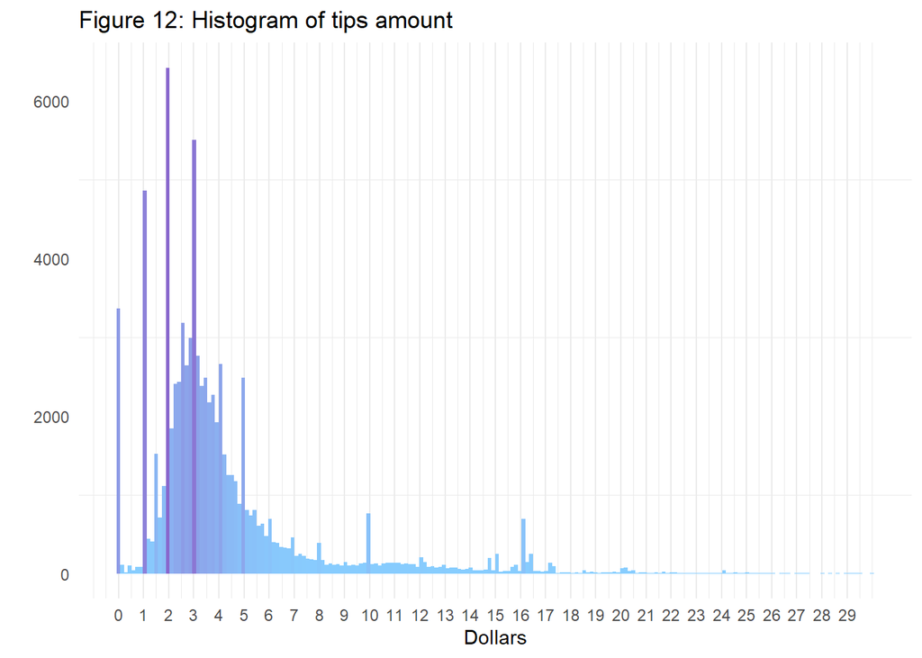

### People prefer to leave even sums (exactly 2, 1 or 3 dollars).

[output not shown]

### If any tips are left, their amount is positively correlated with the total cost of the trip and its distance.

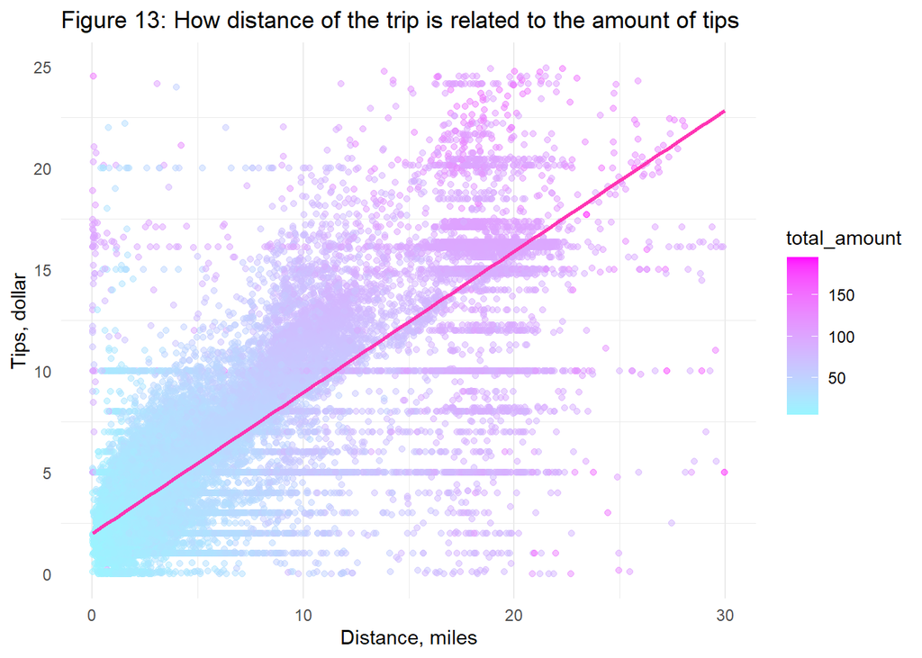

### On average the smallest tips (in proportion to the total cost of the trip) are left in the early morning.

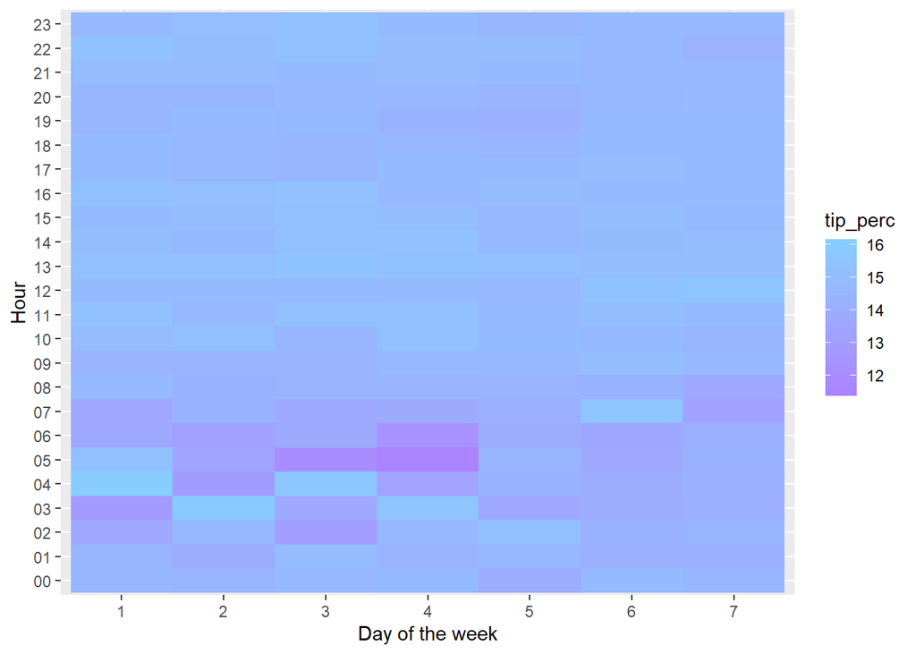

## Location

### Most of the trips take place in Manhattan.

| PU_Borough | count |
| --- | --- |
| Manhattan | 88809 |
| Queens | 9263 |
| Unknown | 1360 |
| Brooklyn | 447 |
| Bronx | 114 |
| Staten Island | 5 |
| EWR | 2 |

| DO_Borough | count |
| --- | --- |
| Manhattan | 89737 |
| Queens | 4807 |
| Brooklyn | 3738 |
| Unknown | 923 |
| Bronx | 535 |
| EWR | 231 |
| Staten Island | 29 |

## Conclusion

#### 4-6 p.m. is the slowest time probably because of the traffic. Although, the amount of tips early in the morning is generally smaller than throughout the day, the average speed is faster, so taxi drivers can benefit from doing longer distance trips (which are related to bigger tips) at that time of the day.